# Classification

2024-03-21

```r
foot = read.csv("D:/BUT STID 2/S2/Classification automatique/Projet/foot.csv", encoding="latin1", sep=";", comment.char="#")
```

```r
library(Hmisc)
library(dplyr)
```

```r
library(ggplot2)
describe(foot$Player)
```

```
## foot$Player
##        n  missing distinct
##      393        0      384
##
## lowest : Aaron Wan-Bissaka  Achraf Hakimi      Adrien Rabiot      Aihen Munoz        Alejandro Garnacho
## highest: Yannick Carrasco   Ylkay Gundodan     Youri Tielemans    Youssoufa Moukoko  Yves Bissouma
```

```r
non_uniques <- foot$Player[duplicated(foot$Player)]
non_uniques
```

```
## [1] "Joao Cancelo"    "Casemiro"        "Joao Felix"      "Wesley Fofana"
## [5] "Arkadiusz Milik" "Leandro Paredes" "Marcel Sabitzer" "Vitinha"
## [9] "Denis Zakaria"
```

```r
foot[foot$Player %in% non_uniques, ]
```

|  | Player | Pos | Squad | Age | Born | MP | Min | Goals | Shots | SoT | ShoDist | PasTotCmp. | PasShoCmp. | PasMedCmp. | PasLonCmp. | PasAss | PPA | PasAtt | CK | SCA | GCA | Tkl | Blocks | Int | Clr | Err | Touches | ToAtt | Carries | … |
| --- | --- | --- | --- | --- | --- | --- | --- | --- | --- | --- | --- | --- | --- | --- | --- | --- | --- | --- | --- | --- | --- | --- | --- | --- | --- | --- | --- | --- | --- | --- |
| 52 | Joao Cancelo | DF | Manchester City | 28 | 1994 | 17 | 1274 | 2 | 1.20 | 0.21 | 22.7 | 84.9 | 93.1 | 84.4 | 65.9 | 0.85 | 2.54 | 85.9 | 0.00 | 2.75 | 0.42 | 2.04 | 0.49 | 1.34 | 0.63 | 0.07 | 96.0 | 4.08 | 58.9 | … |
| 53 | Joao Cancelo | DFFW | Bayern Munich | 28 | 1994 | 2 | 136 | 0 | 0.67 | 0.00 | 7.9 | 78.3 | 89.5 | 78.8 | 45.5 | 2.67 | 2.00 | 70.7 | 0.00 | 3.33 | 0.67 | 2.67 | 2.00 | 1.33 | 3.33 | 0.00 | 86.7 | 6.67 | 43.3 | … |
| 58 | Casemiro | MF | Manchester Utd | 30 | 1992 | 17 | 1230 | 2 | 1.24 | 0.36 | 22.5 | 77.7 | 83.6 | 82.3 | 60.5 | 1.17 | 1.02 | 62.4 | 0.00 | 3.14 | 0.44 | 4.09 | 2.04 | 1.61 | 2.77 | 0.00 | 76.9 | 0.88 | 36.7 | … |
| 59 | Casemiro | MF | Real Madrid | 30 | 1992 | 1 | 8 | 0 | 0.00 | 0.00 | 0.0 | 87.5 | 100.0 | 0.0 | 50.0 | 0.00 | 0.00 | 80.0 | 0.00 | 0.00 | 0.00 | 0.00 | 0.00 | 0.00 | 10.00 | 0.00 | 110.0 | 0.00 | 70.0 | … |
| 112 | Joao Felix | MFFW | Chelsea | 23 | 1999 | 2 | 147 | 1 | 5.63 | 3.75 | 17.8 | 69.6 | 84.4 | 85.0 | 30.0 | 1.88 | 0.63 | 43.1 | 3.75 | 4.38 | 0.00 | 1.88 | 0.00 | 0.00 | 0.00 | 0.00 | 58.1 | 5.00 | 31.3 | … |
| 113 | Joao Felix | FWMF | Atletico Madrid | 23 | 1999 | 14 | 650 | 4 | 3.61 | 1.67 | 18.9 | 75.0 | 86.7 | 70.0 | 37.9 | 1.39 | 1.39 | 31.7 | 0.56 | 4.03 | 0.69 | 1.39 | 0.14 | 0.42 | 0.28 | 0.00 | 44.7 | 3.33 | 29.3 | … |
| 120 | Wesley Fofana | DF | Leicester City | 22 | 2000 | 2 | 180 | 0 | 1.00 | 0.50 | 10.1 | 83.6 | 100.0 | 86.5 | 46.2 | 0.00 | 0.00 | 70.0 | 0.00 | 1.00 | 0.00 | 2.00 | 0.50 | 4.50 | 2.50 | 0.00 | 84.5 | 1.50 | 58.0 | … |
| 121 | Wesley Fofana | DF | Chelsea | 22 | 2000 | 2 | 180 | 0 | 0.50 | 0.00 | 31.8 | 90.5 | 95.3 | 93.5 | 20.0 | 0.00 | 0.00 | 95.0 | 0.00 | 0.50 | 0.00 | 1.50 | 1.00 | 2.50 | 1.50 | 0.00 | 104.5 | 1.00 | 80.5 | … |
| 246 | Arkadiusz Milik | FW | Juventus | 28 | 1994 | 17 | 986 | 6 | 2.64 | 1.45 | 13.9 | 78.1 | 84.4 | 82.9 | 53.8 | 0.73 | 0.55 | 25.4 | 0.00 | 1.82 | 0.27 | 0.64 | 0.64 | 0.00 | 0.82 | 0.00 | 34.6 | 0.91 | 19.1 | … |
| 247 | Arkadiusz Milik | FW | Marseille | 28 | 1994 | 2 | 129 | 0 | 0.71 | 0.00 | 7.8 | 75.7 | 77.8 | 81.8 | 0.0 | 0.71 | 0.00 | 26.4 | 0.00 | 0.00 | 0.00 | 0.71 | 0.00 | 0.00 | 1.43 | 0.00 | 33.6 | 0.71 | 23.6 | … |

[output cut: 8 more lines]

```r
describe(foot$Squad)
```

```
## foot$Squad
##        n  missing distinct
##      393        0       15
##
## lowest : Atletico Madrid Bayern Munich   Chelsea         Dortmund        Inter
## highest: Marseille       Paris S-G       Real Madrid     Real Sociedad   Tottenham
```

```r
foot_unique <- foot[!duplicated(foot$Player),]
```

On garde seulement le poste principale des joueurs avec plusieurs poste

```r
foot_unique$Pos <- ifelse(nchar(foot_unique$Pos) > 2, substr(foot_unique$Pos, 1, 2), foot_unique$Pos)
```

ACP

```r
library(FactoMineR)
```

```r
nvar =  ncol(foot_unique)

# Suppression de la colonne id2
foot_quanti = select(foot_unique,-Player, -Pos, -Squad)

foot_quanti = scale(foot_quanti, center = TRUE, scale = TRUE)


footACP = PCA(foot_quanti, ncp = nvar, graph = F)
summary(footACP)
```

```
##
## Call:
## PCA(X = foot_quanti, ncp = nvar, graph = F)
##
##
## Eigenvalues
##                        Dim.1   Dim.2   Dim.3   Dim.4   Dim.5   Dim.6   Dim.7
## Variance               5.633   4.849   3.228   2.273   1.552   1.453   1.375
## % of var.             17.069  14.693   9.780   6.888   4.703   4.403   4.167
## Cumulative % of var.  17.069  31.763  41.543  48.431  53.134  57.537  61.705
##                        Dim.8   Dim.9  Dim.10  Dim.11  Dim.12  Dim.13  Dim.14
## Variance               1.271   1.153   1.083   0.959   0.919   0.864   0.763
## % of var.              3.850   3.495   3.283   2.905   2.784   2.618   2.311
## Cumulative % of var.  65.555  69.050  72.333  75.239  78.023  80.641  82.952
##                       Dim.15  Dim.16  Dim.17  Dim.18  Dim.19  Dim.20  Dim.21
## Variance               0.716   0.632   0.623   0.538   0.474   0.451   0.400
## % of var.              2.168   1.914   1.887   1.631   1.436   1.366   1.212
## Cumulative % of var.  85.121  87.035  88.921  90.552  91.988  93.355  94.567
##                       Dim.22  Dim.23  Dim.24  Dim.25  Dim.26  Dim.27  Dim.28
## Variance               0.373   0.326   0.247   0.221   0.186   0.145   0.137
## % of var.              1.131   0.987   0.749   0.670   0.563   0.440   0.416
## Cumulative % of var.  95.698  96.685  97.434  98.104  98.668  99.108  99.524
##                       Dim.29  Dim.30  Dim.31  Dim.32  Dim.33
## Variance               0.076   0.053   0.022   0.004   0.003
## % of var.              0.230   0.160   0.065   0.011   0.009
## Cumulative % of var.  99.754  99.914  99.980  99.991 100.000
##
## Individuals (the 10 first)
##                Dist    Dim.1    ctr   cos2    Dim.2    ctr   cos2    Dim.3
## 1          |  3.785 |  1.954  0.176  0.266 | -2.058  0.227  0.295 |  1.316
## 2          |  3.487 | -2.237  0.231  0.412 |  1.183  0.075  0.115 | -0.677
## 3          |  4.109 |  3.530  0.576  0.738 | -0.391  0.008  0.009 |  0.648
## 4          |  4.388 |  3.749  0.650  0.730 | -0.110  0.001  0.001 |  0.446
## 5          |  2.885 |  1.347  0.084  0.218 | -1.426  0.109  0.244 |  1.565
## 6          |  5.782 | -1.397  0.090  0.058 |  1.206  0.078  0.044 |  0.051
## 7          |  4.619 |  3.097  0.444  0.450 |  0.604  0.020  0.017 |  1.150
## 8          |  5.462 |  1.280  0.076  0.055 |  3.483  0.651  0.406 |  1.401
## 9          |  5.884 | -4.158  0.799  0.499 |  1.862  0.186  0.100 | -2.364
## 10         |  5.199 | -0.196  0.002  0.001 | -4.201  0.948  0.653 |  1.582
##               ctr   cos2
```

[output cut: 19 more lines]

```
## SoT        | -0.460  3.749  0.211 |  0.243  1.214  0.059 |  0.209  1.358  0.044
## ShoDist    |  0.168  0.501  0.028 |  0.398  3.273  0.159 |  0.303  2.841  0.092
## PasTotCmp. |  0.645  7.384  0.416 | -0.165  0.560  0.027 |  0.090  0.248  0.008
## PasShoCmp. |  0.465  3.834  0.216 | -0.159  0.522  0.025 |  0.206  1.317  0.043
##
## Age        |
## Born       |
## MP         |
## Min        |
## Goals      |
## Shots      |
## SoT        |
## ShoDist    |
## PasTotCmp. |
## PasShoCmp. |
```

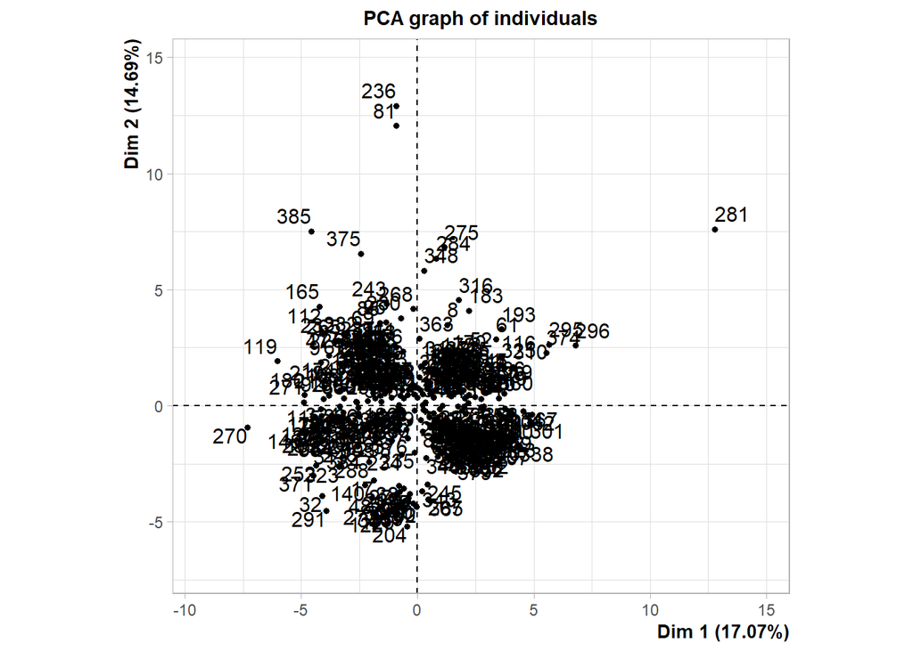

```r
plot(footACP, axes= c(1,2),choix = "ind")
```

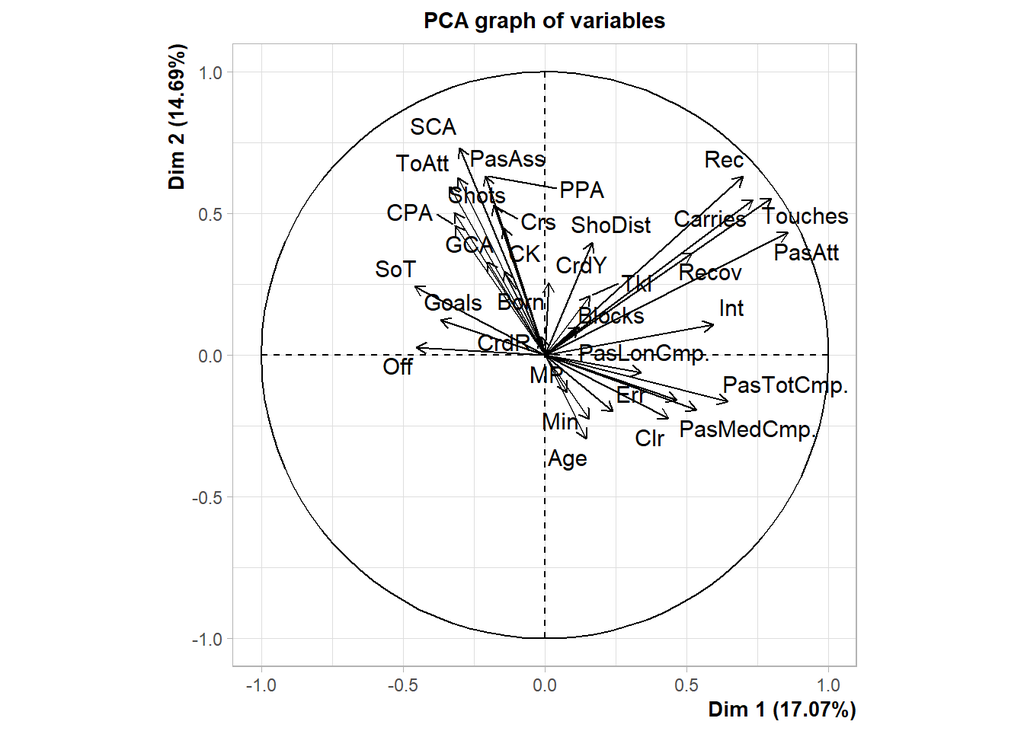

```r
plot(footACP, axes= c(1,2), choix = "var")
```

```r
#footACP$var$contrib

#install.packages('explor')
library(explor)
#explor(footACP)
```

Graphique des individus

```r
res <- explor::prepare_results(footACP)
explor::PCA_ind_plot(res, xax = 1, yax = 2, ind_sup = FALSE, lab_var = NULL,
    ind_lab_min_contrib = 0, col_var = NULL, labels_size = 9, point_opacity = 0.5,
    opacity_var = NULL, point_size = 64, ellipses = FALSE, transitions = TRUE,
    labels_positions = NULL, xlim = c(-11.3, 16.8), ylim = c(-10.2, 17.9))
```

[interactive chart not shown]

Nous pouvons remarquer sur ce graphique que la majorité des points sont proches de l’origine ce qui veut dire qu’ils ne sont pas très bien représentés. Mais il y a quand même des points bien représentés, telles que les points 81 et 236 (qui sont deux joueurs qui se ressemblent) car ils sont assez loin de l’origine, et ils sont aussi fortement corrélés avec l’axe vertical.

Graphique des variables

```r
res <- explor::prepare_results(footACP)
explor::PCA_var_plot(res, xax = 1, yax = 2, var_sup = FALSE, var_sup_choice = ,
    var_lab_min_contrib = 0, col_var = NULL, labels_size = 10, scale_unit = TRUE,
    transitions = TRUE, labels_positions = NULL)
```

[interactive chart not shown]

On peut constater sur ce cercle de corrélation, que les points PasAtt, Touches, Carries et Rec sont très proches du bord du cercle et donc très bien représentés. Les points sont aussi proches les uns des autres, ce qui signifie qu’ils sont fortement correlés positivement. Les points ne sont proches d’aucun axe, ce qui montre que les points sont peu représentés par les deux axes.

Ebouli des valeurs propres

```r
footACP$eig
```

```
##          eigenvalue percentage of variance cumulative percentage of variance
## comp 1  5.632870929           17.069305846                          17.06931
## comp 2  4.848813503           14.693374251                          31.76268
## comp 3  3.227502001            9.780309093                          41.54299
## comp 4  2.272955306            6.887743351                          48.43073
## comp 5  1.552097642            4.703326188                          53.13406
## comp 6  1.452995851            4.403017730                          57.53708
## comp 7  1.375274909            4.167499726                          61.70458
## comp 8  1.270547427            3.850143717                          65.55472
## comp 9  1.153485097            3.495409384                          69.05013
## comp 10 1.083454615            3.283195802                          72.33333
## comp 11 0.958723634            2.905223132                          75.23855
## comp 12 0.918836624            2.784353406                          78.02290
## comp 13 0.864058692            2.618359672                          80.64126
## comp 14 0.762588853            2.310875312                          82.95214
## comp 15 0.715593287            2.168464506                          85.12060
## comp 16 0.631628452            1.914025613                          87.03463
## comp 17 0.622600674            1.886668710                          88.92130
## comp 18 0.538232313            1.631007009                          90.55230
## comp 19 0.473871447            1.435974083                          91.98828
## comp 20 0.450901411            1.366367913                          93.35464
## comp 21 0.399959834            1.211999497                          94.56664
## comp 22 0.373290917            1.131184598                          95.69783
## comp 23 0.325708859            0.986996541                          96.68483
## comp 24 0.247245305            0.749228197                          97.43405
## comp 25 0.221231109            0.670397300                          98.10445
## comp 26 0.185817027            0.563081899                          98.66753
## comp 27 0.145348829            0.440450997                          99.10798
## comp 28 0.137441369            0.416488998                          99.52447
## comp 29 0.075892190            0.229976332                          99.75445
## comp 30 0.052815024            0.160045526                          99.91449
## comp 31 0.021587588            0.065416933                          99.97991
## comp 32 0.003611469            0.010943844                          99.99086
## comp 33 0.003017815            0.009144893                         100.00000
```

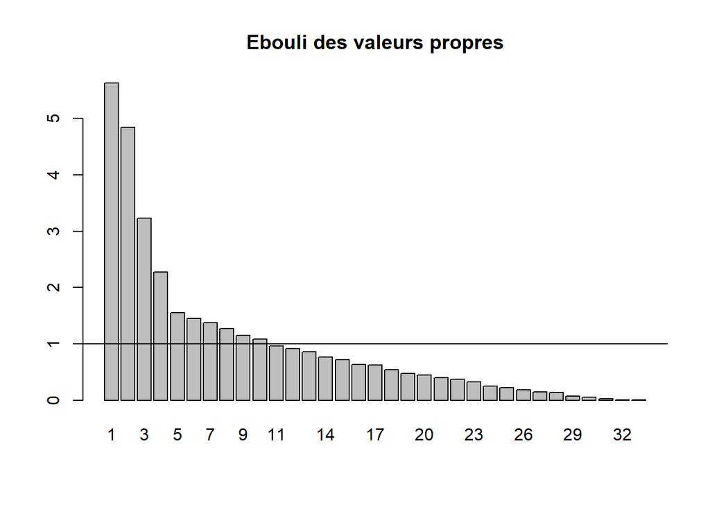

```r
barplot(footACP$eig[,"eigenvalue"], main = "Ebouli des valeurs propres", names.arg = 1:nrow(footACP$eig))
abline(h=1)
```

Classification

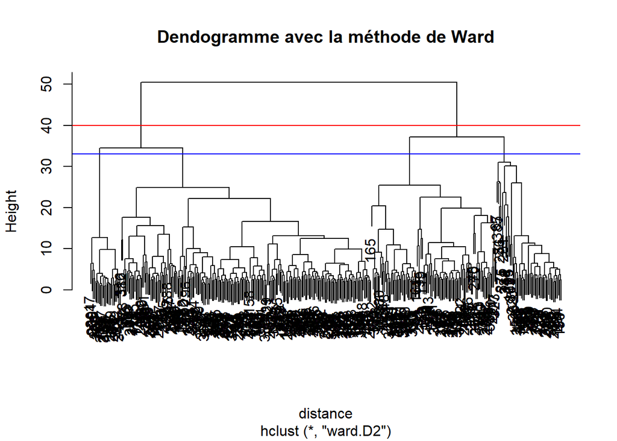

```r
foot_quanti.std = scale(foot_quanti, center = TRUE, scale = TRUE)

distance = dist(foot_quanti.std, method = "euclidean") # matrice des distances entres les points


# Classes avec la méthode de ward

dendro=hclust(distance, method = "ward.D2")
plot(dendro, main = "Dendogramme avec la méthode de Ward")

abline(h=40, col="red")
abline(h=33, col="blue")
```

On fait le choix de séparation, à 2 et à 4.

PseudoF

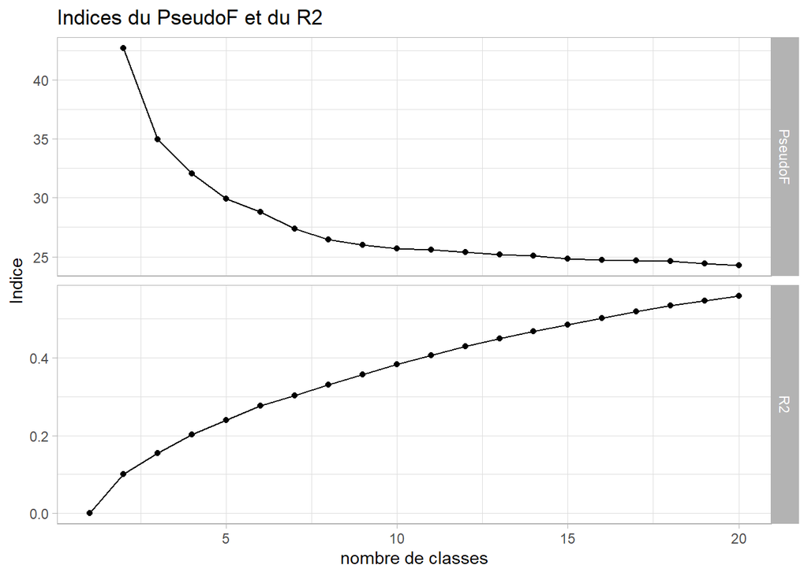

```
## $indices
##    nb_classes        R2  PseudoF
## 1           1 0.0000000       NA
## 2           2 0.1005147 42.68730
## 3           3 0.1550362 34.95344
## 4           4 0.2019699 32.05751
## 5           5 0.2399592 29.91436
## 6           6 0.2759091 28.80678
## 7           7 0.3032332 27.34509
## 8           8 0.3300236 26.45911
## 9           9 0.3566678 25.98782
## 10         10 0.3822402 25.71259
## 11         11 0.4068014 25.57945
## 12         12 0.4288074 25.38809
## 13         13 0.4489411 25.18744
## 14         14 0.4683722 25.07505
## 15         15 0.4852662 24.84824
## 16         16 0.5017030 24.70103
## 17         17 0.5180178 24.65244
## 18         18 0.5335465 24.62612
## 19         19 0.5463771 24.42406
## 20         20 0.5587403 24.25847
##
## $graph
```

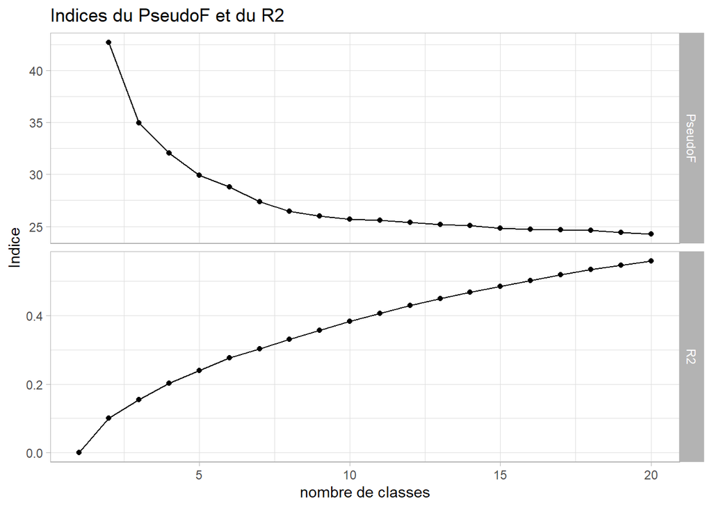

```r
PseudoF.R2 = function(donnees, dendro, cut=20, graph=TRUE){
  library(dplyr)

  n = nrow(donnees)
  nvar = ncol(donnees)

  g = donnees %>% colMeans()
  I = (n-1)/n*sum(diag(var(donnees)))

  Iinter = 0
  R2 = numeric(cut)
  for(i in 2:cut){
    cluster = data.frame(
      cluster = dendro %>% cutree(k = i) %>% factor
    )
    classif = donnees %>% bind_cols(cluster)
    m = classif %>% group_by(cluster) %>% summarise_all(mean) %>% select(-cluster)
    ncl = cluster %>% distinct %>% nrow
    d = numeric(ncl)
    for(j in 1:ncl){
      d[j] = (m[j,]-g)^2 %>% sum
    }
    nb = classif %>%
      group_by(cluster) %>%
      summarise(n=n()) %>%
      select(-cluster)

    Iinter = (1/n)*sum(nb*d)
    R2[i] = Iinter/I
  }

  PseudoF = numeric(cut)
  PseudoF[1] = NA
  if(cut<=(n-1)) ncl = 2:cut else{
    ncl = 2:(n-1)
    PseudoF[cut] = NA
  }
  PseudoF[ncl] = R2[ncl]/(1-R2[ncl])*(n-ncl)/(ncl-1)

  indices = data.frame(
    nb_classes = 1:cut,
    R2 = R2,
    PseudoF = PseudoF
  )

  library(ggplot2)
  library(tidyr)
  indices_long = indices %>%
    gather(-nb_classes, key = "indice", value = "valeur") %>%
    filter(!is.na(valeur))
  g = ggplot(indices_long, aes(nb_classes, valeur))+
    geom_line()+
    geom_point()+
    facet_grid(indice~., scales = "free_y")+
    labs(
      title = "Indices du PseudoF et du R2",
      x = "nombre de classes",
      y = "Indice"
    )+
    theme_light()
  if(graph){
    print(g)
  }
  return(list(indices = indices, graph = g))
}

PseudoF.R2(foot_quanti.std, dendro)
```

Pour le PseudoF ainsi que le R2, on décide de faire 2 classes.